# Client Report - Student Approved Housing Data Analysis

- Show All Code
- Hide All Code

Housing and Student Living Office BYU-Idaho

Author

Kayson Garn

# Student Approved Housing Data Analysis

```r
#loading the occupancy data

occupancy_data <- rio::import("C:\\Users\\kayso\\OneDrive\\Desktop\\BYUI\\Econ Society\\Old Sources\\Clean Part 1\\master_occ_price_management.csv")
```

```r
survey_responses <- rio::import("C:\\Users\\kayso\\OneDrive\\Desktop\\BYUI\\Econ Society\\Old Sources\\Clean Part 1\\master_survey.csv")
```

## Student Approved Housing Overview

BYU–Idaho operates a student-approved housing system designed to support its mission of developing disciple leaders. As part of this model, students must live in approved housing, making the availability, quality, and affordability of these units essential to the student experience. Recent policy adjustments and shifts in admissions trends have raised new questions for current and prospective property developers. This analysis provides a concise overview of the housing landscape in Rexburg, offering data-driven insights to help investors better understand risks, opportunities, and expected market conditions.

## Data Integration & Refinement: The Cleaning Process

To build a comprehensive view of the BYU-Idaho housing landscape, I integrated three distinct data streams: **Occupancy Rates** (0–100%), **Student Surveys** (1–5 scale metrics), and **Contract Pricing**. The primary challenge in this integration was the survey data’s staggered collection schedule, where only one-third of complexes are surveyed each semester.

To ensure a proper analysis despite these gaps, I implemented a multi-stage cleaning and “backfilling” workflow:

### 1. The Initial Join and Gap Analysis

I began by joining the occupancy and pricing data with the available survey responses. By filtering for NA values in metrics like **Cleanliness**, I was able to determine which property-semester combinations lacked survey results.

### 2. Logical Backfilling

To resolve the missing data, I created a custom logic function, choose_best_semester. Since student sentiment often carries over from the most recent period, this function prioritized the “best available” match.

  ```r
  priority_table <- data.frame(
    Missing_Semester = c("Winter (WI)", "Spring (SP)", "Fall (FA)"),
    Priority_1 = c("Fall (FA)", "Fall (FA)", "Winter (WI)"),
    Priority_2 = c("Spring (SP)", "Winter (WI)", "Spring (SP)")
  )

  # Display the table
  pander(priority_table)
  ```

  | Missing_Semester | Priority_1 | Priority_2 |
  | --- | --- | --- |
  | Winter (WI) | Fall (FA) | Spring (SP) |
  | Spring (SP) | Fall (FA) | Winter (WI) |
  | Fall (FA) | Winter (WI) | Spring (SP) |

### 3. Data Coalescing and Schema Finalization

Once the “best match” was identified, I used a coalesce operation to merge the alternate survey data into the master set to “fill the holes” while keeping the primary data intact. I then standardized the column names and removed redundant “join-helper” columns to create a clean master file titled HSL_data.

### 4. Occupancy Organization

To better categorize property performance, I added a binary occupancy indicator (boolocc). This classifies any complex with an occupancy rate of 95% or higher as a “1” (effectively full), allowing for a better comparison between high-demand properties and those with major vacancies.

```r
#now I want to join the price/occupancy and survey results datasets

full_master1 <- occupancy_data %>%
  left_join(survey_responses, by = c("Semester", "Year", "Property"), keep = TRUE)
```

```r
#what data is missing from the survey?
missing_info <- full_master1 %>%
  filter(is.na(Cleanliness))
```

```r
#to create an aleternate survey dataset to do a second merge to catch the semesters we did not get surveys for (we want the survey semesters to be as close to the real semester for the occupancy and price results as possible.)

survey_alt <- survey_responses %>%
  rename(Survey_Semester = Semester)



missing_filled <- missing_info %>%
  left_join(survey_alt, by = c("Property.x" = "Property", "Year.x"="Year"), suffix = c("", "_alt"))

#we want the many to many relationship so that we can 'choose' the "best" semester.
```

```r
#Choose the best semester by logic

choose_best_semester <- function(survey_sem, desired_sem) {

  prefs <- list(
    WI = c("FA", "SP"),
    SP = c("FA", "WI"),
    FA = c("WI", "SP")
  )

  survey_sem %in% prefs[[desired_sem]]
}


missing_best <- missing_filled %>%
  rowwise() %>%
  mutate(is_best = choose_best_semester(Survey_Semester, Semester.x)) %>%
  ungroup() %>%
  filter(is_best) %>%
  distinct(Property.x, Semester.x, Year.x, .keep_all = TRUE)
```

```r
#keep matched rows from the original join

matched <- full_master1 %>%
  filter(!is.na(Cleanliness))
```

```r
#combined matched + backfilled

final_master <- bind_rows(matched, missing_best) %>%
  select(-is_best)
```

```r
#fix duplicate "_alt" columns

alt_cols <- names(final_master)[str_detect(names(final_master), "_alt$")]

for (alt_col in alt_cols) {

  base_col <- str_remove(alt_col, "_alt")

  final_master[[base_col]] <- coalesce(
    final_master[[base_col]],
    final_master[[alt_col]]
  )
}

final_master <- final_master %>%
  select(-all_of(alt_cols)) %>%
  select(-Survey_Semester)
```

```r
HSL_data <- final_master |>
  select(Semester.x, Year.x, Property.x, Total_Beds, `#Occ`, Empty_Beds,  Occ_Rate, Mean_Contract_Price, Management_Name, Gender, Management, Maintenance_Response, Cleanliness, Activities_Events, Internet, Culture, Value,  Overall, n_responses) |>
  rename(Semester = Semester.x, Year= Year.x, Property = Property.x, X.Occ = `#Occ`)
```

| Column Name | Description |
| --- | --- |
| Semester | Winter or Spring semesters. |
| Year | Academic year (2022–2025). |
| Property | Name of the student-approved housing property. |
| Total_Beds | Total number of beds at the property. |
| X.Occ | Number of beds currently occupied. |
| Empty_Beds | Number of beds unoccupied. |
| Occ_Rate | Occupancy rate of the property. |
| Mean_Contract_Price | Mean contract price across all floor plans. |
| Management_Name | Management company for the property. |
| Gender | Gender the property is approved for (Men/Women). |
| Management | Average management survey score (1–5). |
| Maintenance_Response | Average maintenance response score (1–5). |
| Cleanliness | Average cleanliness score (1–5). |
| Activities_Events | Average activities & events score (1–5). |
| Internet | Average internet satisfaction score (1–5). |
| Culture | Average culture score (1–5). |
| Value | Average value rating (1–5). |
| Overall | Overall satisfaction rating (1–5). |

```r
#to create an additional columns creating a boolean variable for occupancy 1=completely full, 0= not completely full

HSL_data <- HSL_data |>
  mutate(Full_Occ = boolocc == 1)
#here instead of boolocc I had OCC_Rate == 1.00 which means that it was 100 percent full instead of the margin of error.

HSL_data <- HSL_data |>
  mutate(
    Management_Name = recode(
      Management_Name,
      "Ball Venture" = "Ball Ventures",
    )
  )
```

# Occupancy Rates

Has occupancy rates increased on average over the last 3 years?

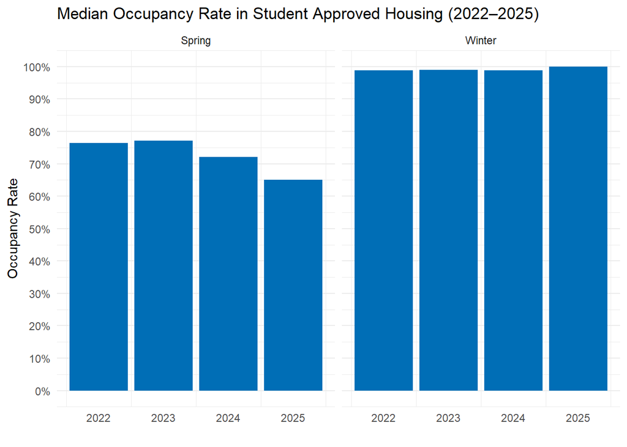

```r
HSL_years_grouped <- HSL_data |>
  group_by(Semester, Year) |>
  summarise(
    mean_price = mean(Mean_Contract_Price),
    median_occ = median(Occ_Rate) * 100
  ) |>
  mutate(
    Semester = case_when(
      Semester == "SP" ~ "Spring",
      Semester == "WI" ~ "Winter"
    )
  )

chart_occupancy <- ggplot(HSL_years_grouped, aes(x = Year, y = median_occ)) +
  geom_bar(stat = "identity", fill="#006EB6") +
  facet_grid(~Semester) +
  scale_y_continuous(
    breaks = seq(0, 100, by = 10),
    labels = function(x) paste0(x, "%"),
    limits = c(0, 100)
  ) +
  theme_minimal() +
  labs(
    title = "Median Occupancy Rate in Student Approved Housing (2022–2025)",
    x = "",
    y = "Occupancy Rate"
  ) +
  theme(
    panel.grid.major.x = element_blank(),
  )

chart_occupancy
```

Despite the overall growth in the student body, this analysis reveals an increasing seasonal volatility in the housing market. While Winter occupancy has trended upward from 2022 to 2025, Spring occupancy has seen a sharp decline, dropping by more than 10% between 2022 and 2025. This divergence indicates that the demand for Student Approved Housing is becoming more cyclical, creating a widening ‘occupancy gap’ that investors must account for when calculating annual returns.

# Market Trend Aggregation & Transformation

To identify the drivers behind the >10% occupancy shift, I transitioned the data set from the individual apartment complex level to an aggregated market summary (`HSL_years_high_occ_grouped`). This cleaning step focuses on two goals: ensuring statistical integrity and making the data understandable for final reporting.

### 1. Integrity Filtering

I began by removing any records where survey results were still missing. This ensures that the subsequent means for maintenance, culture, and value are based on actual resident feedback rather than being skewed by zero-values or empty entries.

### 2. Multi-Metric Summarization

I condensed the dataset by grouping it by **Semester**, **Year**, and **Occupancy Status** (Full_Occ). For each group, I calculated a suite of performance averages:

- Mean contract pricing.
- Mean bed counts to see if complex size impacts occupancy.
- Average scores across all survey categories (Cleanliness, Management, Culture, etc.) to pinpoint which “soft” factors correlate with high occupancy.